# LNM Assignment 3 - Binary Logistic Regression Model

Minh Vo

Goal: Train a binary logistic regression model on the `claim_history.csv`. Your model will predict the likelihood of filing more than one claim in one unit of exposure.

## Library

```r
require(caret)
require(dplyr)
require(MASS)
```

```r
require(ggplot2)
require(bootStepAIC)
require(lmtest)
```

## Code

```r
claim <- read.csv("claim_history.csv")
head(claim)
```

```
##          ID KIDSDRIV     BIRTH AGE HOMEKIDS YOJ INCOME PARENT1 HOME_VAL MSTATUS
## 1  63581743        0 16-Mar-39  60        0  11  67000      No       NA      No
## 2 132761049        0 21-Jan-56  43        0  11  91000      No   257000      No
## 3 921317019        0 18-Nov-51  48        0  11  53000      No       NA      No
## 4 727598473        0  5-Mar-64  35        1  10  16000      No   124000     Yes
## 5 450221861        0  5-Jun-48  51        0  14     NA      No   306000     Yes
## 6 743146596        0 17-May-49  50        0  NA 115000      No   244000     Yes
##   GENDER     EDUCATION   OCCUPATION TRAVTIME    CAR_USE BLUEBOOK TIF CAR_TYPE
## 1      M           PhD Professional       14    Private    14230  11  Minivan
## 2      M   High School  Blue Collar       22 Commercial    14940   1  Minivan
## 3      M     Bachelors      Manager       26    Private    21970   1      Van
## 4      F   High School     Clerical        5    Private     4010   4      SUV
## 5      M Below High Sc  Blue Collar       32    Private    15440   7  Minivan
## 6      F           PhD       Doctor       36    Private    18000   1      SUV
##   RED_CAR REVOKED MVR_PTS CAR_AGE          URBANICITY CLM_AMT CLM_COUNT
## 1     yes      No       3      18 Highly Urban/ Urban       0         0
## 2     yes      No       0       1 Highly Urban/ Urban       0         0
## 3     yes      No       2      10 Highly Urban/ Urban       0         0
## 4      no      No       3      10 Highly Urban/ Urban       0         0
## 5     yes      No       0       6 Highly Urban/ Urban       0         0
## 6      no     Yes       3      17 Highly Urban/ Urban       0         0
##   EXPOSURE
## 1    0.189
## 2    1.000
## 3    1.000
## 4    0.828
## 5    0.729
## 6    0.342
```

```r
#Calculate Frequency
claim <- claim %>% mutate(FREQUENCY = CLM_COUNT/EXPOSURE)

#create a binary target variable EVENT by determining if Frequency >> 1
claim <- claim %>% mutate(EVENT = ifelse(FREQUENCY > 1,1,0))

#New dataset with EVENT as target variable and necessary predictors:
#MSTATUS, CAR_TYPE, REVOKED, and URBANICITY as the categorical predictors
#CAR_AGE, MVR_PTS, TIF, and TRAVTIME as the interval predictors
claim_2 <- claim[,c("MSTATUS", "CAR_TYPE", "REVOKED", "URBANICITY", "CAR_AGE", "MVR_PTS", "TIF", "TRAVTIME","CLM_COUNT","EXPOSURE", "FREQUENCY", "EVENT")]

#Drop all missing values of target variables and predictors
claim_2 <- na.omit(claim_2)
head(claim_2)
```

```
##   MSTATUS CAR_TYPE REVOKED          URBANICITY CAR_AGE MVR_PTS TIF TRAVTIME
## 1      No  Minivan      No Highly Urban/ Urban      18       3  11       14
## 2      No  Minivan      No Highly Urban/ Urban       1       0   1       22
## 3      No      Van      No Highly Urban/ Urban      10       2   1       26
## 4     Yes      SUV      No Highly Urban/ Urban      10       3   4        5
## 5     Yes  Minivan      No Highly Urban/ Urban       6       0   7       32
## 6     Yes      SUV     Yes Highly Urban/ Urban      17       3   1       36
##   CLM_COUNT EXPOSURE FREQUENCY EVENT
## 1         0    0.189         0     0
## 2         0    1.000         0     0
## 3         0    1.000         0     0
## 4         0    0.828         0     0
## 5         0    0.729         0     0
## 6         0    0.342         0     0
```

### Question 1

A. For each predictor, generate a line chart that shows the odds of the Event by the predictor’s unique values. The predictor’s unique values are displayed in ascending lexical order.

```r
# Calculate and plot the odds of the Event by each predictor's unique value

odds_MSTATUS <- claim_2 %>%
  group_by(MSTATUS) %>%
  summarize(mean_Event = mean(EVENT)) %>%
  mutate(odds_MSTATUS = mean_Event / (1 - mean_Event))
odds_CARTYPE <- claim_2 %>%
  group_by(CAR_TYPE) %>%
  summarize(mean_Event = mean(EVENT)) %>%
  mutate(odds_CARTYPE = mean_Event / (1 - mean_Event))
odds_REVOKED <- claim_2 %>%
  group_by(REVOKED) %>%
  summarize(mean_Event = mean(EVENT)) %>%
  mutate(odds_REVOKED = mean_Event / (1 - mean_Event))
odds_URBANICITY <- claim_2 %>%
  group_by(URBANICITY) %>%
  summarize(mean_Event = mean(EVENT)) %>%
  mutate(odds_URBANICITY = mean_Event / (1 - mean_Event))
odds_CARAGE <- claim_2 %>%
  group_by(CAR_AGE) %>%
  summarize(mean_Event = mean(EVENT)) %>%
  mutate(odds_CARAGE = mean_Event / (1 - mean_Event))
odds_MVRPTS <- claim_2 %>%
  group_by(MVR_PTS) %>%
  summarise(mean_Event = mean(EVENT)) %>%
  mutate(odds_MVRPTS = mean_Event/(1 - mean_Event))
odds_TIF <- claim_2 %>%
  group_by(TIF) %>%
  summarise(mean_Event = mean(EVENT)) %>%
  mutate(odds_TIF = mean_Event/(1 - mean_Event))
odds_TRAVTIME <- claim_2 %>%
  group_by(TRAVTIME) %>%
  summarise(mean_Event = mean(EVENT)) %>%
  mutate(odds_TRAVTIME = mean_Event/(1 - mean_Event))

ggplot(odds_MSTATUS, aes(x = MSTATUS, y = odds_MSTATUS, group = 1)) + geom_line() + ggtitle("Odds of EVENT by MSTATUS")
```

[figure not shown]

```r
ggplot(odds_CARTYPE, aes(x = CAR_TYPE, y = odds_CARTYPE, group = 1)) + geom_line() + ggtitle("Odds of EVENT by CAR TYPE")
```

[figure not shown]

```r
ggplot(odds_REVOKED, aes(x = REVOKED, y = odds_REVOKED, group = 1)) + geom_line() + ggtitle("Odds of EVENT by REVOKED")
```

[figure not shown]

```r
ggplot(odds_URBANICITY,aes(x = URBANICITY, y = odds_URBANICITY, group = 1)) + geom_line() + ggtitle("Odds of EVENT by URBAN & CITY")
```

[figure not shown]

```r
ggplot(odds_CARAGE,aes(x = CAR_AGE, y = odds_CARAGE, group = 1)) + geom_line() + ggtitle("Odds of EVENT by AGE OF CAR")
```

[figure not shown]

```r
ggplot(odds_MVRPTS,aes(x = MVR_PTS, y = odds_MVRPTS, group = 1)) + geom_line() + ggtitle("Odds of EVENT by MVR PTS")
```

[figure not shown]

```r
ggplot(odds_TIF,aes(x = TIF, y = odds_TIF, group = 1)) + geom_line() + ggtitle("Odds of EVENT by TIF")
```

[figure not shown]

```r
ggplot(odds_TRAVTIME,aes(x = TRAVTIME, y = odds_TRAVTIME, group = 1)) + geom_line() + ggtitle("Odds of EVENT by TRAVTIME")
```

[figure not shown]

B. The Entry Threshold is 0.05. Please provide a detailed report of the Forward Selection.

```r
# Encoding some categorical predictors
claim_2$MSTATUS <- ifelse(claim_2$MSTATUS == "Yes",1,0)
claim_2$REVOKED <- ifelse(claim_2$REVOKED == "Yes",1,0)
claim_2$URBANICITY <- ifelse(claim_2$URBANICITY == "Highly Urban/ Urban",1,0)
dmy <- dummyVars(" ~ .", data = claim_2, fullRank = T)
claim_3 <- data.frame(predict(dmy, newdata = claim_2))

#Convert some features to factor
#claim_2$EVENT <- as.factor(claim_2$EVENT)
#claim_2$MSTATUS <- as.factor(claim_2$MSTATUS)
#claim_2$CAR_TYPE <- as.factor(claim_2$CAR_TYPE)
#claim_2$REVOKED <- as.factor(claim_2$REVOKED)
#claim_2$URBANICITY <- as.factor(claim_2$URBANICITY)

# Fit a full generalized linear model with all predictors above
glm1 <- glm(EVENT~.-CLM_COUNT-EXPOSURE-FREQUENCY,data = claim_3,family = binomial(link = "logit"))
summary(glm1)
```

```
##
## Call:
## glm(formula = EVENT ~ . - CLM_COUNT - EXPOSURE - FREQUENCY, family = binomial(link = "logit"),
##     data = claim_3)
##
## Deviance Residuals:
##     Min       1Q   Median       3Q      Max
## -1.9717  -0.7610  -0.4943  -0.1433   2.9403
##
## Coefficients:
##                      Estimate Std. Error z value Pr(>|z|)
## (Intercept)         -3.304583   0.141582 -23.340  < 2e-16 ***
## MSTATUS             -0.636946   0.052083 -12.229  < 2e-16 ***
## CAR_TYPEPanel.Truck  0.553739   0.104735   5.287 1.24e-07 ***
## CAR_TYPEPickup       0.732984   0.082066   8.932  < 2e-16 ***
## CAR_TYPESports.Car   0.948175   0.091057  10.413  < 2e-16 ***
## CAR_TYPESUV          0.643630   0.074023   8.695  < 2e-16 ***
## CAR_TYPEVan          0.479323   0.102470   4.678 2.90e-06 ***
## REVOKED              0.783806   0.069734  11.240  < 2e-16 ***
## URBANICITY           2.079243   0.104049  19.983  < 2e-16 ***
## CAR_AGE             -0.058881   0.004669 -12.610  < 2e-16 ***
## MVR_PTS              0.163794   0.011133  14.712  < 2e-16 ***
## TIF                 -0.048859   0.006560  -7.448 9.49e-14 ***
## TRAVTIME             0.014944   0.001674   8.928  < 2e-16 ***
## ---
## Signif. codes:  0 '***' 0.001 '**' 0.01 '*' 0.05 '.' 0.1 ' ' 1
##
## (Dispersion parameter for binomial family taken to be 1)
##
##     Null deviance: 10827.9  on 9661  degrees of freedom
## Residual deviance:  9208.3  on 9649  degrees of freedom
## AIC: 9234.3
##
## Number of Fisher Scoring iterations: 5
```

```r
# Fit a basic GLM with only intercept
basic.glm <- glm(EVENT~1,data = claim_3, family = binomial)
summary(basic.glm)
```

```
##
## Call:
## glm(formula = EVENT ~ 1, family = binomial, data = claim_3)
##
## Deviance Residuals:
##     Min       1Q   Median       3Q      Max
## -0.7553  -0.7553  -0.7553  -0.7553   1.6695
##
## Coefficients:
##             Estimate Std. Error z value Pr(>|z|)
## (Intercept) -1.10830    0.02355  -47.06   <2e-16 ***
## ---
## Signif. codes:  0 '***' 0.001 '**' 0.01 '*' 0.05 '.' 0.1 ' ' 1
##
## (Dispersion parameter for binomial family taken to be 1)
##
##     Null deviance: 10828  on 9661  degrees of freedom
## Residual deviance: 10828  on 9661  degrees of freedom
## AIC: 10830
##
## Number of Fisher Scoring iterations: 4
```

```r
#Forward Selection
forwards = step(basic.glm, scope=list(lower=formula(basic.glm),upper=formula(glm1)), direction="forward")
```

```
## Start:  AIC=10829.94
## EVENT ~ 1
##
##                       Df Deviance   AIC
## + URBANICITY           1    10250 10254
## + MVR_PTS              1    10398 10402
## + REVOKED              1    10624 10628
## + MSTATUS              1    10687 10691
## + CAR_AGE              1    10726 10730
## + TIF                  1    10766 10770
## + CAR_TYPESports.Car   1    10788 10792
## + TRAVTIME             1    10801 10805
## + CAR_TYPEPickup       1    10809 10813
## + CAR_TYPESUV          1    10820 10824
## <none>                      10828 10830
## + CAR_TYPEVan          1    10828 10832
## + CAR_TYPEPanel.Truck  1    10828 10832
##
## Step:  AIC=10253.78
## EVENT ~ URBANICITY
##
##                       Df Deviance     AIC
## + MVR_PTS              1   9938.5  9944.5
## + CAR_AGE              1  10052.1 10058.1
## + REVOKED              1  10091.3 10097.3
## + MSTATUS              1  10102.8 10108.8
## + TRAVTIME             1  10163.9 10169.9
## + TIF                  1  10182.7 10188.7
## + CAR_TYPESports.Car   1  10197.2 10203.2
## + CAR_TYPEPickup       1  10229.0 10235.0
## + CAR_TYPESUV          1  10235.2 10241.2
## <none>                    10249.8 10253.8
## + CAR_TYPEPanel.Truck  1  10248.6 10254.6
## + CAR_TYPEVan          1  10248.7 10254.7
##
## Step:  AIC=9944.53
## EVENT ~ URBANICITY + MVR_PTS
##
##                       Df Deviance    AIC
## + CAR_AGE              1   9769.5 9777.5
```

[output cut: 106 more lines]

```
## <none>                     9246.6 9268.6
##
## Step:  AIC=9253.68
## EVENT ~ URBANICITY + MVR_PTS + CAR_AGE + MSTATUS + REVOKED +
##     TRAVTIME + TIF + CAR_TYPESports.Car + CAR_TYPEPickup + CAR_TYPESUV +
##     CAR_TYPEPanel.Truck
##
##               Df Deviance    AIC
## + CAR_TYPEVan  1   9208.3 9234.3
## <none>             9229.7 9253.7
##
## Step:  AIC=9234.34
## EVENT ~ URBANICITY + MVR_PTS + CAR_AGE + MSTATUS + REVOKED +
##     TRAVTIME + TIF + CAR_TYPESports.Car + CAR_TYPEPickup + CAR_TYPESUV +
##     CAR_TYPEPanel.Truck + CAR_TYPEVan
```

```r
summary(forwards)
```

```
##
## Call:
## glm(formula = EVENT ~ URBANICITY + MVR_PTS + CAR_AGE + MSTATUS +
##     REVOKED + TRAVTIME + TIF + CAR_TYPESports.Car + CAR_TYPEPickup +
##     CAR_TYPESUV + CAR_TYPEPanel.Truck + CAR_TYPEVan, family = binomial,
##     data = claim_3)
##
## Deviance Residuals:
##     Min       1Q   Median       3Q      Max
## -1.9717  -0.7610  -0.4943  -0.1433   2.9403
##
## Coefficients:
##                      Estimate Std. Error z value Pr(>|z|)
## (Intercept)         -3.304583   0.141582 -23.340  < 2e-16 ***
## URBANICITY           2.079243   0.104049  19.983  < 2e-16 ***
## MVR_PTS              0.163794   0.011133  14.712  < 2e-16 ***
## CAR_AGE             -0.058881   0.004669 -12.610  < 2e-16 ***
## MSTATUS             -0.636946   0.052083 -12.229  < 2e-16 ***
## REVOKED              0.783806   0.069734  11.240  < 2e-16 ***
## TRAVTIME             0.014944   0.001674   8.928  < 2e-16 ***
## TIF                 -0.048859   0.006560  -7.448 9.49e-14 ***
## CAR_TYPESports.Car   0.948175   0.091057  10.413  < 2e-16 ***
## CAR_TYPEPickup       0.732984   0.082066   8.932  < 2e-16 ***
## CAR_TYPESUV          0.643630   0.074023   8.695  < 2e-16 ***
## CAR_TYPEPanel.Truck  0.553739   0.104735   5.287 1.24e-07 ***
## CAR_TYPEVan          0.479323   0.102470   4.678 2.90e-06 ***
## ---
## Signif. codes:  0 '***' 0.001 '**' 0.01 '*' 0.05 '.' 0.1 ' ' 1
##
## (Dispersion parameter for binomial family taken to be 1)
##
##     Null deviance: 10827.9  on 9661  degrees of freedom
## Residual deviance:  9208.3  on 9649  degrees of freedom
## AIC: 9234.3
##
## Number of Fisher Scoring iterations: 5
```

```r
#glm1_boot <- boot.stepAIC(glm1,data=claim_2,B=50)
#glm1_boot
```

The forward selection gave the final model with all 8 features: “MSTATUS”, “CAR_TYPE”, “REVOKED”, “URBANICITY”, “CAR_AGE”, “MVR_PTS”, “TIF”, “TRAVTIME”

```r
#Log-likelihood
logLik(glm1) #-4604.172(df=13)
```

```
## 'log Lik.' -4604.172 (df=13)
```

```r
anova(basic.glm,glm1,test = "Chi")
```

```
## Analysis of Deviance Table
##
## Model 1: EVENT ~ 1
## Model 2: EVENT ~ (MSTATUS + CAR_TYPEPanel.Truck + CAR_TYPEPickup + CAR_TYPESports.Car +
##     CAR_TYPESUV + CAR_TYPEVan + REVOKED + URBANICITY + CAR_AGE +
##     MVR_PTS + TIF + TRAVTIME + CLM_COUNT + EXPOSURE + FREQUENCY) -
##     CLM_COUNT - EXPOSURE - FREQUENCY
##   Resid. Df Resid. Dev Df Deviance  Pr(>Chi)
## 1      9661    10827.9
## 2      9649     9208.3 12   1619.6 < 2.2e-16 ***
## ---
## Signif. codes:  0 '***' 0.001 '**' 0.01 '*' 0.05 '.' 0.1 ' ' 1
```

```r
#Deviance Chi-squares statistic
glm1$null.deviance - glm1$deviance
```

```
## [1] 1619.599
```

```r
#Deviance degree-of-freedom
df.residual(glm1)
```

```
## [1] 9649
```

```r
#Chi-square significance
pchisq(glm1$deviance, glm1$df.residual, lower.tail = FALSE)
```

```
## [1] 0.999352
```

The forward selection gave the final model with all 8 features in the original model. Here is the detailed report:  
* Predictors entered: “MSTATUS”, “CAR_TYPE”, “REVOKED”, “URBANICITY”, “CAR_AGE”, “MVR_PTS”, “TIF”, and “TRAVTIME”  
* Log-Likelihood value: -4604.172  
* Deviance Chi-square statistic: 1619.6  
Null Deviance: 10827.9  
- Residual Deviance: 9208.3  
* Deviance degree-of-freedom: 9649  
* Chi-square significance: 0.999352  
The chi-square test for the Residual variance give p-value > 0.05, which means that the model fits well.

```r
summary(glm1)
```

```
##
## Call:
## glm(formula = EVENT ~ . - CLM_COUNT - EXPOSURE - FREQUENCY, family = binomial(link = "logit"),
##     data = claim_3)
##
## Deviance Residuals:
##     Min       1Q   Median       3Q      Max
## -1.9717  -0.7610  -0.4943  -0.1433   2.9403
##
## Coefficients:
##                      Estimate Std. Error z value Pr(>|z|)
## (Intercept)         -3.304583   0.141582 -23.340  < 2e-16 ***
## MSTATUS             -0.636946   0.052083 -12.229  < 2e-16 ***
## CAR_TYPEPanel.Truck  0.553739   0.104735   5.287 1.24e-07 ***
## CAR_TYPEPickup       0.732984   0.082066   8.932  < 2e-16 ***
## CAR_TYPESports.Car   0.948175   0.091057  10.413  < 2e-16 ***
## CAR_TYPESUV          0.643630   0.074023   8.695  < 2e-16 ***
## CAR_TYPEVan          0.479323   0.102470   4.678 2.90e-06 ***
## REVOKED              0.783806   0.069734  11.240  < 2e-16 ***
## URBANICITY           2.079243   0.104049  19.983  < 2e-16 ***
## CAR_AGE             -0.058881   0.004669 -12.610  < 2e-16 ***
## MVR_PTS              0.163794   0.011133  14.712  < 2e-16 ***
## TIF                 -0.048859   0.006560  -7.448 9.49e-14 ***
## TRAVTIME             0.014944   0.001674   8.928  < 2e-16 ***
## ---
## Signif. codes:  0 '***' 0.001 '**' 0.01 '*' 0.05 '.' 0.1 ' ' 1
##
## (Dispersion parameter for binomial family taken to be 1)
##
##     Null deviance: 10827.9  on 9661  degrees of freedom
## Residual deviance:  9208.3  on 9649  degrees of freedom
## AIC: 9234.3
##
## Number of Fisher Scoring iterations: 5
```

```r
params <- coef(glm1)
exp_params <- exp(params)
table <- data.frame(params, exp_params)
colnames(table) <- c("Parameter Estimates", "Exponential of Parameter Estimates")
table
```

```
##                     Parameter Estimates Exponential of Parameter Estimates
## (Intercept)                 -3.30458316                         0.03671451
## MSTATUS                     -0.63694609                         0.52890519
## CAR_TYPEPanel.Truck          0.55373887                         1.73974556
## CAR_TYPEPickup               0.73298420                         2.08128232
## CAR_TYPESports.Car           0.94817525                         2.58099569
## CAR_TYPESUV                  0.64363022                         1.90337804
## CAR_TYPEVan                  0.47932297                         1.61498064
## REVOKED                      0.78380572                         2.18979016
## URBANICITY                   2.07924257                         7.99840835
## CAR_AGE                     -0.05888065                         0.94281929
## MVR_PTS                      0.16379374                         1.17797132
## TIF                         -0.04885916                         0.95231525
## TRAVTIME                     0.01494426                         1.01505648
```

### Question 2

Please color-code the markers according to the Exposure value. Also, please briefly comment on the graphs. A. Plot the predicted Event probability versus the observed Frequency. B. Plot the Deviance residuals versus the observed Frequency.

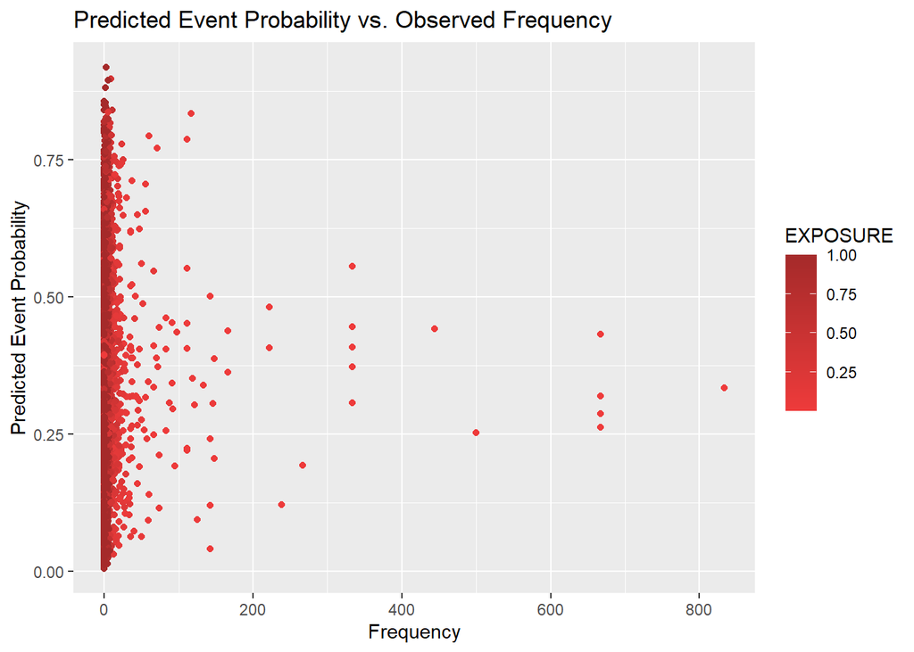

```r
# Calculating the predicted Event probability
pred_event <- predict(glm1, type = "response")

# Plot the predicted Event probability versus the observed Frequency
ggplot(claim_3, aes(x = FREQUENCY, y = pred_event, color = EXPOSURE)) +
  geom_point() +
  scale_color_continuous(name = "EXPOSURE", low = "brown2", high = "brown") +
  xlab("Frequency") +
  ylab("Predicted Event Probability") +
  ggtitle("Predicted Event Probability vs. Observed Frequency")
```

The visualization measures how the probability of Event is predicted accurately compared to the observed frequency. It is color-coded by Exposure feature: the darker the color is, the higher the Exposure is. It can be seen that the predicted probability of Event has the highest values when the Frequency is equal to 0, given the Exposure equal to 1. As the frequency increases, particularly up to 200 and more, the Exposure and prediction values of Event tend to get lower. The data points on the right of the chart (where frequency is over 800) implies the outlier of the data.

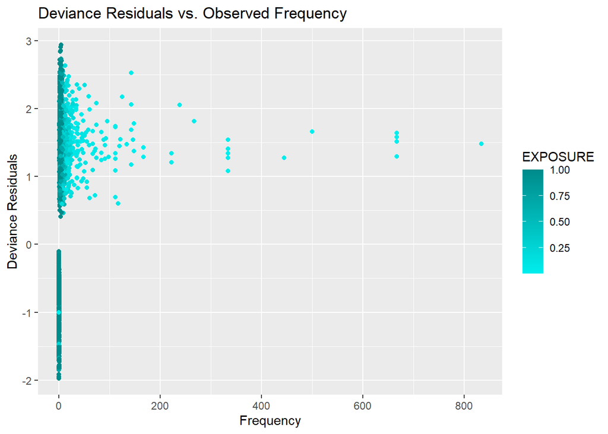

```r
# Calculating the deviance residual
dv_resid <- residuals(glm1,type = "deviance")

# Plot the predicted Event probability versus the observed Frequency
ggplot(claim_3, aes(x = FREQUENCY, y = dv_resid, color = EXPOSURE)) +
  geom_point() +
  scale_color_continuous(name = "EXPOSURE", low = "cyan2", high = "cyan4") +
  xlab("Frequency") +
  ylab("Deviance Residuals") +
  ggtitle("Deviance Residuals vs. Observed Frequency")
```

The chart plots the residuals of the model versus the observed frequency, which measures how inaccurate the model is compared to the actual result. There are also negative residuals, which are mostly distributed at the frequency of 0. By looking at the chart, we can also identify some more outliers in the dataset shown by the data points as frequency increases up to more than 600.

### Question 3

Calculate the Accuracy metric to assess your final model in Question 3.

```r
# Classifying the predicted Event probability: defined it as Event = 1 if predicted value >= 0.25
event_classification <- ifelse(pred_event >= 0.25, 1, 0)

Event <- data.frame(event_classification, claim_3$EVENT)
colnames(Event) <- c("Predicted", "Actual")

#Calculate the accuracy metric
accuracy <- (sum(Event$Actual==Event$Predicted))/length(Event$Actual)
accuracy
```

```
## [1] 0.675326
```

The final model predicted the probability of the Event (when the Frequency is strictly greater than one) with the accuracy of 67.53%